# Tutorial 2

# Tutorial 2

# Libraries

```r
library(dplyr)
library(tidyverse)
library(psych)
library(magrittr)
library(reshape2)
```

# Question 3

The survey contains the results from 20 customers on broadband internet service.

- The customers’ income X1
- Age X2
- Education X3 (in years)
- Expenses on internet service X4 (per month)
- Hours of service X5 (per day)
- the type of internet they used Y
  - (1-PCCW Ltd.; 2-New World Telecommunications Ltd.; 3-Pacific Internet (HK) Ltd.)

## EDA

```r
internet <- read.csv("~/MSTAT/STAT8019_Marketing_Analytics/data/TUT0301.csv")
str(internet)
```

```
'data.frame':   20 obs. of  7 variables:
 $ case   : Factor w/ 20 levels "c1","c10","c11",..: 1 12 14 15 16 17 18 19 20 2 ...
 $ income : int  18800 14300 12000 12000 16600 34700 21100 16600 36900 23400 ...
 $ age    : int  44 36 36 30 41 47 33 34 49 33 ...
 $ edu    : int  17 15 16 16 17 18 16 20 19 16 ...
 $ expense: int  600 100 600 400 750 720 610 770 890 740 ...
 $ hours  : int  7 4 8 6 7 9 6 10 9 12 ...
 $ Y      : int  3 1 1 1 3 2 1 3 2 3 ...
```

```r
head(internet)
```

|  | case | income | age | edu | expense | hours | Y |
| --- | --- | --- | --- | --- | --- | --- | --- |
| 1 | c1 | 18800 | 44 | 17 | 600 | 7 | 3 |
| 2 | c2 | 14300 | 36 | 15 | 100 | 4 | 1 |
| 3 | c3 | 12000 | 36 | 16 | 600 | 8 | 1 |
| 4 | c4 | 12000 | 30 | 16 | 400 | 6 | 1 |
| 5 | c5 | 16600 | 41 | 17 | 750 | 7 | 3 |
| 6 | c6 | 34700 | 47 | 18 | 720 | 9 | 2 |

```r
describe(internet, skew = F, ranges = F)
```

|  | vars | n | mean | sd | se |
| --- | --- | --- | --- | --- | --- |
| case* | 1 | 20 | 10.50 | 5.92 | 1.32 |
| income | 2 | 20 | 21780.00 | 7681.94 | 1717.73 |
| age | 3 | 20 | 37.95 | 6.46 | 1.44 |
| edu | 4 | 20 | 16.95 | 1.47 | 0.33 |
| expense | 5 | 20 | 647.00 | 174.84 | 39.10 |
| hours | 6 | 20 | 8.20 | 2.48 | 0.56 |
| Y | 7 | 20 | 1.95 | 0.89 | 0.20 |

### Distribution Plot

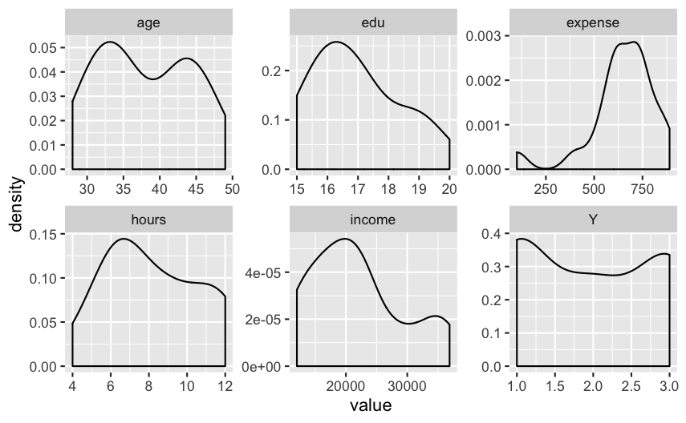

```r
internet%>%
  keep(is.numeric) %>%                     # Keep only numeric columns
  gather() %>%                             # Convert to key-value pairs
  ggplot(aes(value)) +                     # Plot the values
    facet_wrap(~ key, scales = "free") +   # In separate panels
    geom_density()
```

## Hierarchicul Clustering

### Standardization

```r
# Use standard scaling on variables
# exclude Y , hence only 5 variables to cluster
internet_sc <- scale(internet[, 2:6]) ; internet_sc
```

```
          income        age         edu     expense       hours
 [1,] -0.3879228  0.9365032  0.03405806 -0.26881523 -0.48316364
 [2,] -0.9737123 -0.3018481 -1.32826417 -3.12855177 -1.69107273
 [3,] -1.2731158 -0.3018481 -0.64710306 -0.26881523 -0.08052727
 [4,] -1.2731158 -1.2306117 -0.64710306 -1.41270985 -0.88580000
 [5,] -0.6743088  0.4721215  0.03405806  0.58910573 -0.48316364
 [6,]  1.6818667  1.4008850  0.71521917  0.41752153  0.32210909
 [7,] -0.0885193 -0.7662299 -0.64710306 -0.21162050 -0.88580000
 [8,] -0.6743088 -0.6114360  2.07754140  0.70349519  0.72474545
 [9,]  1.9682527  1.7104728  1.39638028  1.38983196  0.32210909
[10,]  0.2108842 -0.7662299 -0.64710306  0.53191100  1.53001818
[11,]  0.2108842 -0.3018481  0.03405806  0.41752153  1.53001818
[12,]  0.7966737  0.6269154 -0.64710306  0.30313207 -0.48316364
[13,]  1.0960772  1.0912971  1.39638028  1.16105303  1.12738182
[14,] -0.0885193  0.9365032  0.71521917  1.04666357 -0.88580000
[15,] -0.0885193 -1.5401995  0.03405806 -0.55478889 -1.28843636
[16,] -0.3879228 -1.0758177 -0.64710306 -0.78356781 -0.48316364
[17,]  0.2108842  0.6269154  0.03405806 -0.15442577  1.12738182
[18,] -1.2731158 -0.7662299 -1.32826417 -0.09723104  0.32210909
[19,] -0.6743088 -1.2306117 -1.32826417 -0.04003631 -0.88580000
[20,]  1.6818667  1.0912971  1.39638028  0.36032680  1.53001818
attr(,"scaled:center")
  income      age      edu  expense    hours
21780.00    37.95    16.95   647.00     8.20
attr(,"scaled:scale")
     income         age         edu     expense       hours
7681.940544    6.460202    1.468081  174.841281    2.483631
```

### Proximity Matrix (using Squared Euclidean Distance)

```r
internet_dist <- dist(internet_sc, method = "euclidean")^2
round((internet_dist), 3)
```

```
        1      2      3      4      5      6      7      8      9     10     11     12
2  13.370
3   2.943 11.326
4   7.415  5.009  2.820
5   1.034 17.825  2.320  7.891
6   6.083 30.755 14.120 22.321  7.556
7   3.618 10.620  2.271  3.062  3.144 11.541
8   9.058 32.306  9.472 15.238  6.822 11.701 11.222
9  11.406 44.597 21.645 32.646 11.662  1.587 18.564 13.472
10  8.416 25.857  5.653 12.036  6.837 10.188  6.479  8.909 15.593
11  6.416 26.209  5.731 12.715  5.465  6.986  7.001  5.785 11.398  0.693
12  2.290 17.696  5.636 10.841  2.734  3.900  3.152 12.740  8.552  6.389  5.736
13  8.721 39.993 15.233 25.857  8.295  2.104 14.967  6.869  1.845  8.968  5.295  7.811
14  2.446 24.574  7.172 14.004  1.394  5.205  6.339  7.307  6.870 10.946  8.319  3.450
15  6.954 10.959  4.942  2.861  6.350 15.787  1.343 11.018 23.029 10.277 10.512  7.328
```

[output cut: 25 more lines]

### Ward’s Method as Distance Between Clusters

```r
internet_fit <- hclust(internet_dist, method = "ward.D")
summary(internet_fit)
```

```
            Length Class  Mode
merge       38     -none- numeric
height      19     -none- numeric
order       20     -none- numeric
labels       0     -none- NULL
method       1     -none- character
call         3     -none- call
dist.method  1     -none- character
```

#### Merging History

```r
# get merging history
internet_history <- cbind(internet_fit$merge, internet_fit$height)
internet_history
```

```
      [,1] [,2]       [,3]
 [1,]   -7  -16  0.6747269
 [2,]  -10  -11  0.6927158
 [3,]   -3  -18  0.8711881
 [4,]   -1   -5  1.0336957
 [5,]  -13  -20  1.1464279
 [6,]  -19    1  1.3331811
 [7,]   -6   -9  1.5872296
 [8,]  -14    4  2.2157540
 [9,]  -15    6  2.2655077
[10,]  -17    2  2.6956613
[11,]    5    7  3.1109771
[12,]   -4    9  3.1433248
[13,]  -12    8  3.4246466
[14,]    3   12  6.5720444
[15,]   -8   10 10.1957309
[16,]   -2   14 15.8837001
[17,]   13   15 17.6765774
[18,]   11   17 28.8292539
[19,]   16   18 86.6476569
```

### Selecting Appropriate Number of Clusters

#### Distance plot

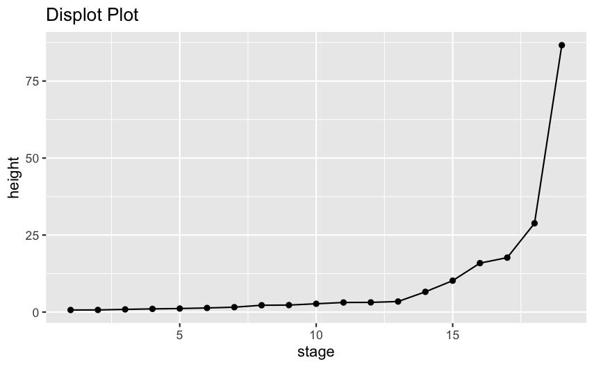

```r
ggplot(mapping=aes(x=1:length(internet_fit$height),y=internet_fit$height))+
  geom_line()+
  geom_point()+
  labs(x="stage",y="height") + ggtitle("Displot Plot")
```

- The elbow above is at 3 clusters, hence 3 clusters are optimum and suggested

#### Dendogram

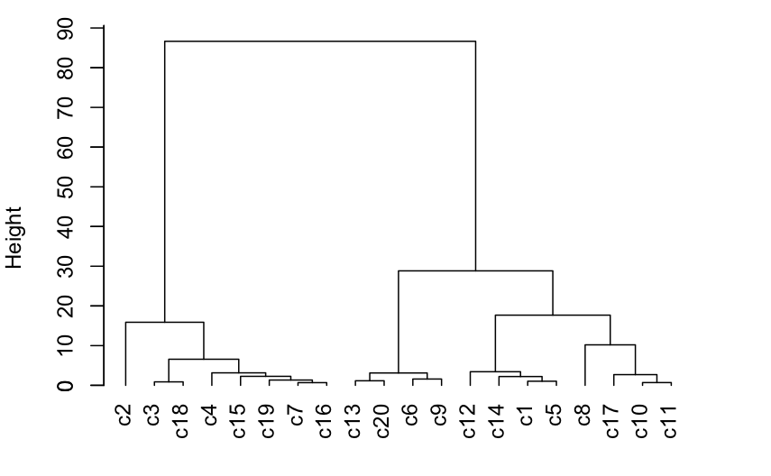

```r
par(mar=c(1,4,1,3))
plot(internet_fit,labels=internet$case,hang=-1,main="")
axis(side = 2, at = seq(0, 100, 10))
```

### Cluster Analysis

```r
internet_clusters <- cutree(internet_fit, k=3)
internet_case <- internet$case
internet_sol <- data.frame(internet_clusters, internet_sc, internet_case)
internet_sol[order(internet_sol$internet_clusters), c("internet_clusters", "internet_case")]
```

|  | internet_clusters | internet_case |
| --- | --- | --- |
| 1 | 1 | c1 |
| 5 | 1 | c5 |
| 8 | 1 | c8 |
| 10 | 1 | c10 |
| 11 | 1 | c11 |
| 12 | 1 | c12 |
| 14 | 1 | c14 |
| 17 | 1 | c17 |
| 2 | 2 | c2 |
| 3 | 2 | c3 |

[output cut: 10 more lines]

#### Interpreting Cluster Characteristics

```r
#cluster means
tb<-aggregate(x=internet_sol[,2:6], by=list(cluster=internet_sol$internet_clusters),FUN=mean)
print(tb,digits=2)
```

| cluster | income | age | edu | expense | hours |
| --- | --- | --- | --- | --- | --- |
| 1 | -0.04946667 | 0.2399306 | 0.2043483 | 0.3960735 | 0.3221091 |
| 2 | -0.75404124 | -0.9016746 | -0.8173933 | -0.8121652 | -0.7348114 |
| 3 | 1.60701582 | 1.3234880 | 1.2260900 | 0.8321833 | 0.8254045 |

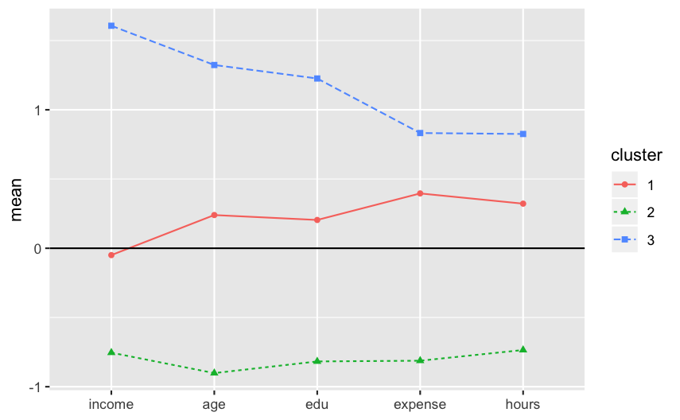

```r
#profile plot
tbm<-melt(tb,id.vars='cluster')
tbm$cluster<-factor(tbm$cluster)
ggplot(tbm,
       aes(x = variable, y = value, group = cluster, colour = cluster)) +
  geom_line(aes(linetype=cluster))+
  geom_point(aes(shape=cluster)) +
  geom_hline(yintercept=0) +
  labs(x=NULL,y="mean")
```

- C1: Middle class people and lifestyle
- C2: Low income, younger, people, perhaps fresh grads
- C3: High income lifestyle

#### Numbers of customers in clusters

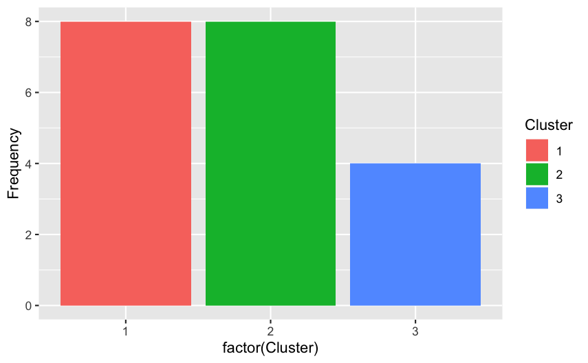

```r
tbl <- as.data.frame(table(internet_sol$internet_clusters))

colnames(tbl) <- c("Cluster", "Frequency")

ggplot(tbl, aes(factor(Cluster), Frequency, fill = Cluster)) +
  geom_col(position = 'dodge')
```

### Telco Company serves Which Cluster

```r
telco_clust <- tibble(telco=internet$Y , clusters = internet_sol$internet_clusters)

prop.table(table(telco_clust), 2)
```

```
     clusters
telco     1     2     3
    1 0.000 1.000 0.000
    2 0.125 0.000 1.000
    3 0.875 0.000 0.000
```

(1-PCCW Ltd.; 2-New World Telecommunications Ltd.; 3-Pacific Internet (HK) Ltd.)

- PCCW mostly low income people younger people
- New World High income older people who uses more internet
- Pacific internet serves the middle income people

# Question 4

## EDA

```r
secondary <- read.csv("~/MSTAT/STAT8019_Marketing_Analytics/data/TUT0302.csv")
str(secondary)
```

```
'data.frame':   40 obs. of  7 variables:
 $ case   : Factor w/ 40 levels "c1","c10","c11",..: 1 12 23 34 36 37 38 39 40 2 ...
 $ English: int  87 35 90 13 85 83 87 41 87 68 ...
 $ Math   : int  23 21 98 5 98 99 22 24 14 77 ...
 $ Chinese: int  86 25 98 15 95 88 88 26 78 68 ...
 $ Science: int  87 37 94 26 84 88 91 25 77 64 ...
 $ Music  : int  85 37 84 26 94 90 92 15 83 78 ...
 $ PE     : int  93 17 83 40 95 87 89 30 86 75 ...
```

```r
head(secondary)
```

|  | case | English | Math | Chinese | Science | Music | PE |
| --- | --- | --- | --- | --- | --- | --- | --- |
| 1 | c1 | 87 | 23 | 86 | 87 | 85 | 93 |
| 2 | c2 | 35 | 21 | 25 | 37 | 37 | 17 |
| 3 | c3 | 90 | 98 | 98 | 94 | 84 | 83 |
| 4 | c4 | 13 | 5 | 15 | 26 | 26 | 40 |
| 5 | c5 | 85 | 98 | 95 | 84 | 94 | 95 |
| 6 | c6 | 83 | 99 | 88 | 88 | 90 | 87 |

```r
describe(secondary, skew = F, ranges = F)
```

|  | vars | n | mean | sd | se |
| --- | --- | --- | --- | --- | --- |
| case* | 1 | 40 | 20.50 | 11.69 | 1.85 |
| English | 2 | 40 | 67.70 | 26.34 | 4.17 |
| Math | 3 | 40 | 48.42 | 33.41 | 5.28 |
| Chinese | 4 | 40 | 70.30 | 27.05 | 4.28 |
| Science | 5 | 40 | 68.33 | 26.96 | 4.26 |
| Music | 6 | 40 | 67.47 | 28.11 | 4.44 |
| PE | 7 | 40 | 70.60 | 25.47 | 4.03 |

### Distribution Plot

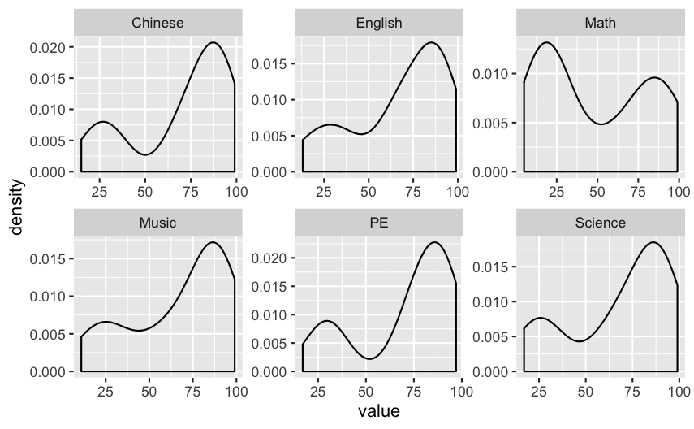

```r
secondary %>%
  keep(is.numeric) %>%                     # Keep only numeric columns
  gather() %>%                             # Convert to key-value pairs
  ggplot(aes(value)) +                     # Plot the values
    facet_wrap(~ key, scales = "free") +   # In separate panels
    geom_density()
```

### Correlation Plot

```r
cormat <- secondary %>%
  keep(is.numeric) %>%
    cor() %>%
      round(2)

cormat
```

```
        English Math Chinese Science Music   PE
English    1.00 0.43    0.93    0.95  0.93 0.94
Math       0.43 1.00    0.53    0.49  0.41 0.50
Chinese    0.93 0.53    1.00    0.95  0.93 0.96
Science    0.95 0.49    0.95    1.00  0.93 0.94
Music      0.93 0.41    0.93    0.93  1.00 0.93
PE         0.94 0.50    0.96    0.94  0.93 1.00
```

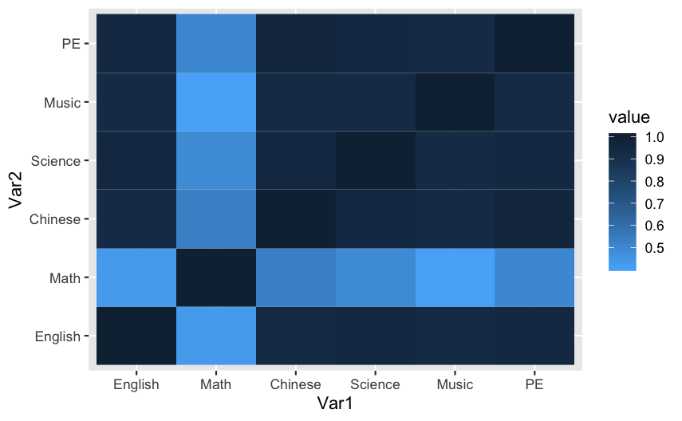

```r
melted_cormat <- melt(cormat)
ggplot(data = melted_cormat, aes(x=Var1, y=Var2, fill=value)) +
  geom_tile() + scale_fill_continuous(high = "#132B43", low = "#56B1F7")
```

## K-Means Clustering

```r
# Standard scaling

secondary_sc <- secondary %>%
  keep(is.numeric) %>%
    scale()

secondary_sc
```

```
          English       Math     Chinese     Science       Music
 [1,]  0.73261257 -0.7609046  0.58032529  0.69274234  0.62347130
 [2,] -1.24126585 -0.8207595 -1.67444176 -1.16198949 -1.08418191
 [3,]  0.84649017  1.4836518  1.02388602  0.95240479  0.58789519
 [4,] -2.07636826 -1.2995982 -2.04407570 -1.57003049 -1.47551910
 [5,]  0.65669417  1.4836518  0.91299584  0.58145843  0.94365628
 [6,]  0.58077577  1.5135792  0.65425208  0.72983697  0.80135184
 [7,]  0.73261257 -0.7908320  0.65425208  0.84112088  0.87250406
 [8,] -1.01351065 -0.7309772 -1.63747836 -1.60712512 -1.86685629
 [9,]  0.73261257 -1.0302514  0.28461814  0.32179597  0.55231908
[10,]  0.01138776  0.8551760 -0.08501581 -0.16043430  0.37443854
[11,] -1.88657226 -0.7010498 -1.30480782 -1.71840903 -2.00916073
[12,]  0.96036777 -0.9105417  0.54336190  1.06368870  0.58789519
[13,]  0.61873497  1.2442324  1.06084941  0.65564770  0.51674298
[14,]  0.46689817 -0.6711224  1.02388602  0.80402624  0.73019963
```

[output cut: 73 more lines]

### MacQueen (default)

```r
set.seed(12345)

fit_mq <- kmeans(x=secondary_sc, centers = 4, algorithm = "MacQueen")

fit_mq
```

```
K-means clustering with 4 clusters of sizes 9, 10, 10, 11

Cluster means:
      English       Math     Chinese     Science       Music
1  0.84227248  1.3107378  0.86781836  0.82463438  0.76972864
2 -1.54493946 -0.9524401 -1.60051497 -1.57003049 -1.53244087
3 -0.04555104  0.6845897  0.09240849  0.03987673 -0.05603237
4  0.75676842 -0.8289215  0.66097269  0.71634801  0.81428861
          PE
1  0.8007922
2 -1.6212116
3  0.1334654
4  0.6973030

Clustering vector:
 [1] 4 2 1 2 1 1 4 2 4 3 2 4 1 4 4 2 1 4 3 2 4 1 3 2 3 3 1 4 2 3 4
[32] 3 3 1 2 4 3 2 1 3

Within cluster sum of squares by cluster:
[1] 1.897916 4.395582 4.189757 2.725637
 (between_SS / total_SS =  94.4 %)

Available components:

[1] "cluster"      "centers"      "totss"        "withinss"
[5] "tot.withinss" "betweenss"    "size"         "iter"
[9] "ifault"
```

### Hartigan Wong

```r
fit_hw <- kmeans(x=secondary_sc, centers = 4, algorithm = "Hartigan-Wong")
fit_hw
```

```
K-means clustering with 4 clusters of sizes 1, 6, 3, 30

Cluster means:
     English       Math   Chinese    Science      Music
1 -1.2412659 -0.8207595 -1.674442 -1.1619895 -1.0841819
2 -1.3867761 -0.9354812 -1.514267 -1.5700305 -1.7482693
3 -1.9624907 -1.0302514 -1.748369 -1.7060442 -1.2502037
4  0.5149798  0.3174800  0.533505  0.5233435  0.5108136
          PE
1 -2.1040422
2 -1.5741062
3 -1.5544790
4  0.5404039

Clustering vector:
 [1] 4 1 4 3 4 4 4 2 4 4 2 4 4 4 4 2 4 4 4 2 4 4 4 2 4 4 4 4 2 4 4
[32] 4 4 4 3 4 4 3 4 4

Within cluster sum of squares by cluster:
[1]  0.0000000  1.5701700  0.7059492 52.3067347
 (between_SS / total_SS =  76.7 %)

Available components:

[1] "cluster"      "centers"      "totss"        "withinss"
[5] "tot.withinss" "betweenss"    "size"         "iter"
[9] "ifault"
```

- K-Means using MacQueen is a better fit based on the BSS/TSS ratio

## Hierarchical Clustering

Use its centroids for K means

```r
secondary_dist <- secondary_sc %>%
  dist(method="euclidean")

secondary_dist <- secondary_dist^2
```

```r
second_hclust_fit <- hclust(secondary_dist, method = "ward.D")
ward.sol <- cutree(second_hclust_fit, k=4)
```

```r
# save the centers of each column
tb<-aggregate(secondary_sc,by=list(ward=ward.sol),FUN=mean)
tb
```

| ward | English | Math | Chinese | Science | Music | PE |
| --- | --- | --- | --- | --- | --- | --- |
| 1 | 0.75676842 | -0.8289215 | 0.66097269 | 0.71634801 | 0.81428861 | 0.6973030 |
| 2 | -1.54493946 | -0.9524401 | -1.60051497 | -1.57003049 | -1.53244087 | -1.6212116 |
| 3 | 0.84227248 | 1.3107378 | 0.86781836 | 0.82463438 | 0.76972864 | 0.8007922 |
| 4 | -0.04555104 | 0.6845897 | 0.09240849 | 0.03987673 | -0.05603237 | 0.1334654 |

```r
NA
```

### Feed Centroids into K Means

```r
fit_k_w <- kmeans(x=secondary_sc, centers = tb[, 2:ncol(tb)], algorithm = "MacQueen")
fit_k_w
```

```
K-means clustering with 4 clusters of sizes 11, 10, 9, 10

Cluster means:
      English       Math     Chinese     Science       Music
1  0.75676842 -0.8289215  0.66097269  0.71634801  0.81428861
2 -1.54493946 -0.9524401 -1.60051497 -1.57003049 -1.53244087
3  0.84227248  1.3107378  0.86781836  0.82463438  0.76972864
4 -0.04555104  0.6845897  0.09240849  0.03987673 -0.05603237
          PE
1  0.6973030
2 -1.6212116
3  0.8007922
4  0.1334654

Clustering vector:
 [1] 1 2 3 2 3 3 1 2 1 4 2 1 3 1 1 2 3 1 4 2 1 3 4 2 4 4 3 1 2 4 1
[32] 4 4 3 2 1 4 2 3 4

Within cluster sum of squares by cluster:
[1] 2.725637 4.395582 1.897916 4.189757
 (between_SS / total_SS =  94.4 %)

Available components:

[1] "cluster"      "centers"      "totss"        "withinss"
[5] "tot.withinss" "betweenss"    "size"         "iter"
[9] "ifault"
```

- Verify that we get back the same results are the `hclust` using Ward’s method

```r
fit_k_w$cluster == ward.sol
```

```
 [1] TRUE TRUE TRUE TRUE TRUE TRUE TRUE TRUE TRUE TRUE TRUE TRUE
[13] TRUE TRUE TRUE TRUE TRUE TRUE TRUE TRUE TRUE TRUE TRUE TRUE
[25] TRUE TRUE TRUE TRUE TRUE TRUE TRUE TRUE TRUE TRUE TRUE TRUE
[37] TRUE TRUE TRUE TRUE
```

### Cluster Analysis

#### Cluster Members

```r
as.data.frame(table(fit_k_w$cluster))
```

| Var1 | Freq |
| --- | --- |
| 1 | 11 |
| 2 | 10 |
| 3 | 9 |
| 4 | 10 |

- Classes are almost balanced

#### Means of Clusters

```r
second_comb <- data.frame(cluster=fit_k_w$cluster, secondary_sc) ; second_comb
```

| cluster | English | Math | Chinese | Science | Music | PE |
| --- | --- | --- | --- | --- | --- | --- |
| 1 | 0.73261257 | -0.7609046 | 0.58032529 | 0.69274234 | 0.62347130 | 0.87930123 |
| 2 | -1.24126585 | -0.8207595 | -1.67444176 | -1.16198949 | -1.08418191 | -2.10404223 |
| 3 | 0.84649017 | 1.4836518 | 1.02388602 | 0.95240479 | 0.58789519 | 0.48675604 |
| 2 | -2.07636826 | -1.2995982 | -2.04407570 | -1.57003049 | -1.47551910 | -1.20118829 |
| 3 | 0.65669417 | 1.4836518 | 0.91299584 | 0.58145843 | 0.94365628 | 0.95781027 |
| 3 | 0.58077577 | 1.5135792 | 0.65425208 | 0.72983697 | 0.80135184 | 0.64377412 |
| 1 | 0.73261257 | -0.7908320 | 0.65425208 | 0.84112088 | 0.87250406 | 0.72228315 |
| 2 | -1.01351065 | -0.7309772 | -1.63747836 | -1.60712512 | -1.86685629 | -1.59373348 |
| 1 | 0.73261257 | -1.0302514 | 0.28461814 | 0.32179597 | 0.55231908 | 0.60451960 |
| 4 | 0.01138776 | 0.8551760 | -0.08501581 | -0.16043430 | 0.37443854 | 0.17271988 |

[output cut: 30 more lines]

```r
second_tb <- second_comb %>%
  group_by(cluster) %>%
    summarise_all(list(mean=mean)) ; second_tb
```

| cluster | English_mean | Math_mean | Chinese_mean | Science_mean | Music_mean | PE_mean |
| --- | --- | --- | --- | --- | --- | --- |
| 1 | 0.75676842 | -0.8289215 | 0.66097269 | 0.71634801 | 0.81428861 | 0.6973030 |
| 2 | -1.54493946 | -0.9524401 | -1.60051497 | -1.57003049 | -1.53244087 | -1.6212116 |
| 3 | 0.84227248 | 1.3107378 | 0.86781836 | 0.82463438 | 0.76972864 | 0.8007922 |
| 4 | -0.04555104 | 0.6845897 | 0.09240849 | 0.03987673 | -0.05603237 | 0.1334654 |

#### Line Plot

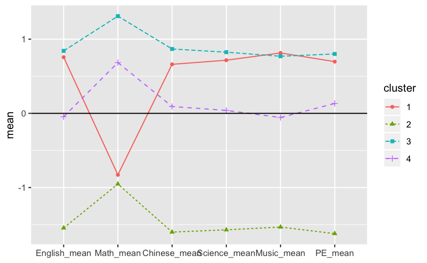

```r
#profile plot
tbm<-melt(second_tb,id.vars='cluster')
tbm$cluster<-factor(tbm$cluster)
ggplot(tbm,
       aes(x = variable, y = value, group = cluster, colour = cluster)) +
  geom_line(aes(linetype=cluster))+
  geom_point(aes(shape=cluster)) +
  geom_hline(yintercept=0) +
  labs(x=NULL,y="mean")
```

### Class Characteristics

- C1: Students who are good in other subjects except Math
- C2: Students who are not good in any subjects
- C3: Students who are good in every sunject, especially Math
- C$: Students who are moderate in every subject